# Test A Perceptual Phenomenon

The Stroop effect is a demonstration of interference in the reaction time of a task.

#### (1) What is the independent variable? What is the dependent variable?

Independent Variable : Congruent or Incongruent condition

Dependent Variable : Time taken to complete each test by the same subject

#### (2a) What is the hypothesis?

Ho: uc - ui = 0

H1: uc - ui != 0, where uc=congruent mean and ui=incongruent mean

The null of our hypothesis is that ui subtracted from uc is zero whereas the alternate is that it is not equal to zero.

#### (2b) What is the statistical test used?

```python
import pandas as pd
import numpy as np
import math
import seaborn as sns
%matplotlib inline
df = pd.read_csv("stroopdata.csv")
```

```python
#Calculating standard deviation and mean of the sample values of the congruent test
con_mean=df['Congruent'].mean()
con_std=df['Congruent'].values.std(ddof=1)
print("Congruent mean = "+str(con_mean)+"\nCongruent sample standard deviation = "+str(con_std))
```

```
Congruent mean = 14.051125000000004
Congruent sample standard deviation = 3.5593579576451955
```

```python
#Calculating standard deviation and mean of the sample values of the incongruent test
incon_mean=df['Incongruent'].mean()
incon_std=df['Incongruent'].values.std(ddof=1)
print("Incongruent mean = "+str(incon_mean)+"\nIncongruent sample standard deviation = "+str(incon_std))
```

```
Incongruent mean = 22.01591666666667
Incongruent sample standard deviation = 4.797057122469138
```

We are performing a dependent paired samples two-tailed t-test.

Taking significance level to be 0.05, and calculating the degrees of freedom to be 23, we find the t-critical value.

The t-critical value turns out to be 2.069.

We used a t-test as we plotted the values to find a near normal-distribution along with the fact that we are unaware of the population parameters.

Also, since the sample size was small (n<30), a t-test was the better choice over a z-test.

#### (3) Report some descriptive statistics regarding this dataset. Include at least one measure of central tendency and at least one measure of variability.

```python
#already loaded csv file
df.head()
```

|  | Congruent | Incongruent |
| --- | --- | --- |
| 0 | 12.079 | 19.278 |
| 1 | 16.791 | 18.741 |
| 2 | 9.564 | 21.214 |
| 3 | 8.630 | 15.687 |
| 4 | 14.669 | 22.803 |

```python
df['Time difference']=df['Incongruent']-df['Congruent']
print("Congruent time mean = "+str(con_mean))
print("Congruent sample standard deviation = "+str(con_std))
```

```
Congruent time mean = 14.051125000000004
Congruent sample standard deviation = 3.5593579576451955
```

```python
print("Incongruent time mean = "+str(incon_mean))
print("Incongruent sample standard deviation = "+str(incon_std))
print("Time differnce mean = "+str(df['Time difference'].mean())+"\nTime difference standard deviation = "+str(df['Time difference'].values.std(ddof=1)))
```

```
Incongruent time mean = 22.01591666666667
Incongruent sample standard deviation = 4.797057122469138
Time differnce mean = 7.964791666666667
Time difference standard deviation = 4.864826910359056
```

```python
df.head()
```

|  | Congruent | Incongruent | Time difference |
| --- | --- | --- | --- |
| 0 | 12.079 | 19.278 | 7.199 |
| 1 | 16.791 | 18.741 | 1.950 |
| 2 | 9.564 | 21.214 | 11.650 |
| 3 | 8.630 | 15.687 | 7.057 |
| 4 | 14.669 | 22.803 | 8.134 |

The time difference values show that the incongruent time is greater. Also, the mean and standard deviation of the time difference column further helps confirm the rejection of the null hypothesis.

#### (4) Provide one or two visualizations that show the distribution of the sample data. Write one or two sentences noting what you observe about the plot or plots.

[output not shown]

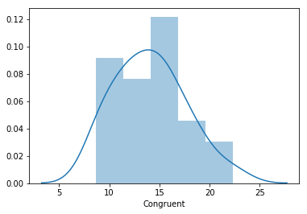

```python
sns.distplot(df['Congruent'])
```

[output not shown]

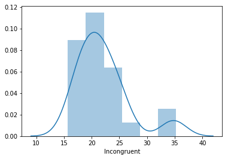

```python
sns.distplot(df['Incongruent'])
```

The congruent test graph looks like a normally-distributed plot as the calculated mean = 14.051 is pretty close to the peak.

#### (5) Perform the statistical test and interpret your results

```python
df.head()
```

|  | Congruent | Incongruent | Time difference |
| --- | --- | --- | --- |
| 0 | 12.079 | 19.278 | 7.199 |
| 1 | 16.791 | 18.741 | 1.950 |
| 2 | 9.564 | 21.214 | 11.650 |
| 3 | 8.630 | 15.687 | 7.057 |
| 4 | 14.669 | 22.803 | 8.134 |

```python
stddev_diff=df['Time difference'].values.std(ddof=1)
std_error=stddev_diff/math.sqrt(df['Congruent'].count())
std_error
```

```
0.9930286347783406
```

```python
t_stat=(incon_mean-con_mean)/std_error
t_stat
```

```
8.020706944109955
```

As our t-statistic is greater than t-critical value for a significance level of 0.05 or p<0.025 where p is the tail probability.

Using Graphpad's p-value calculator, we found that:

The two-tailed P value is less than 0.0001

By conventional criteria, this difference is considered to be extremely statistically significant.

Calculating the confidence interval, we find that:

```python
print("The confidence interval is : ({},{})".format(((incon_mean-con_mean)-(2.069*std_error)),((incon_mean-con_mean)+(2.069*std_error))))
```

```
The confidence interval is : (5.910215421310278,10.019367912023052)
```

### Result

Thus, based on our statistical analysis, we reject the null hypothesis and conclude that the Stroop effect was infact in play. This was unsurprising as we could already see from the initial data analysis that the difference in the timings of the two tests was significant and positive. The p-value helps us acertain that the difference is extremely statistically significant.

### Bibliography

http://www.mit.edu/~6.s085/notes/lecture2.pdf

https://www.dataquest.io/blog/python-data-visualization-libraries/

https://stackoverflow.com/questions/25140998/pandas-compute-mean-or-std-standard-deviation-over-entire-dataframe

https://www.graphpad.com/quickcalcs/pValue1/

https://s3.amazonaws.com/udacity-hosted-downloads/t-table.jpg